# Is There Room for Social Justice in Statistics?

October 23, 2017

## Does Social Justice Have a Place in Statistics?

Social justice is a concept of *fair* and *just* relations between the individual and society.

The concept of social justice has often referred to the process of *ensuring* that individuals receive what is their due from society.

## Circularity

### The efforts to understand social factors have the effect of emphasizing racial/ethnic/gender differences

## Modeling Child IQ

*National Longitudinal Survey of Youth, Gelman et. al*:

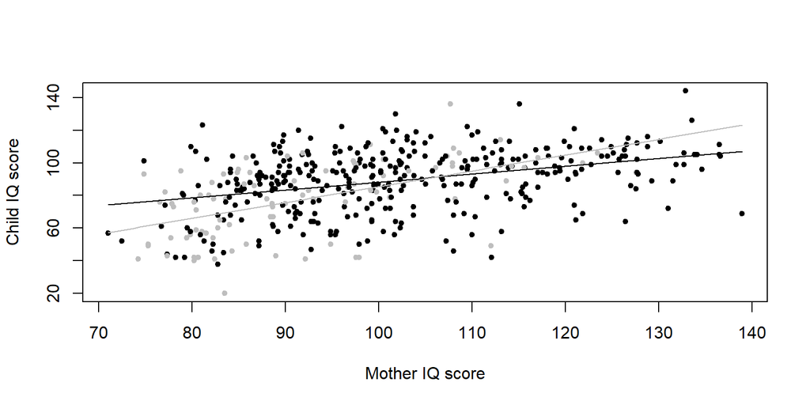

## Intelligence Factors

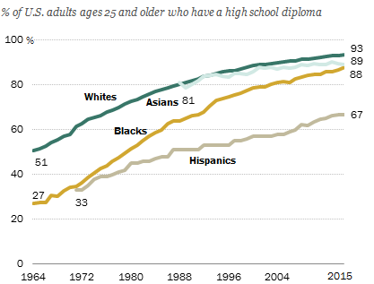

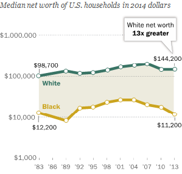

## Model Shortfalls

- **What social factors that impact a child's intelligence are absent from this statistical model?**
- **How is circularity at play in these factors?**

## Modeling Coaching Programs

*8 Schools, Gelman et. al*:

A study was performed for the Educational Testing Service to analyze the effects of special coaching programs on test scores. Separate randomized experiments were performed to estimate the effects of coaching programs for the SAT-V in each of eight high schools. The outcome variable in each study was the score on a special administration of the SAT-V, between 200 and 800. Also, there was no prior reason to believe that any of the eight programs was more effective than any other or that some were more similar in effect to each other than to any other.

## Inference

The problem is interested in the estimated coaching effects, \(\bar{y}_j,\) and their sampling variances, \(\sigma^2.\)

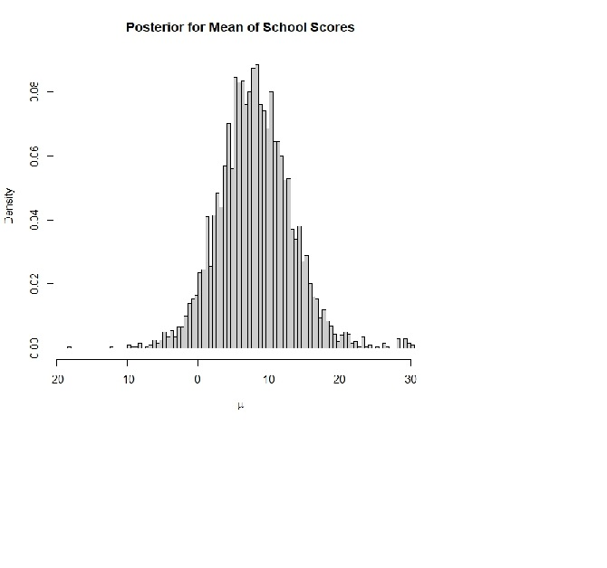

## Achievement Impacts

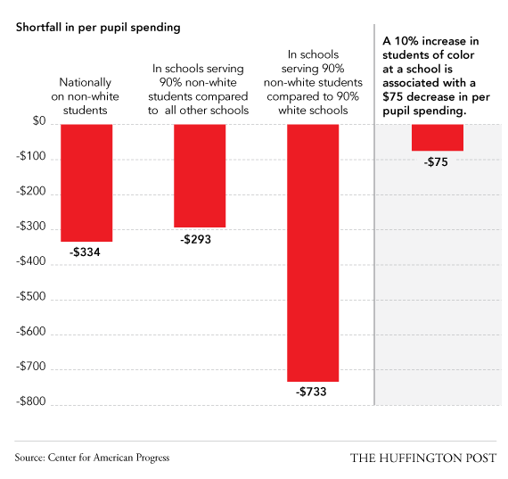

## Modeling Shortfalls

- **What social factors that impact a child's achievement are absent from this statistical model?**
- **How is circularity at play in these factors?**

## Earnings

*Survey of American Adults in 1990, Gelman et. al:*

```
## lm(formula = log(earn) ~ height + eth + female, data = heights.clean)
```

|  | Estimate | Std. Error | t value | Pr(>\|t\|) |
| --- | --- | --- | --- | --- |
| **(Intercept)** | 8.479 | 0.6661 | 12.73 | 1.214e-34 |
| **height** | 0.01461 | 0.01021 | 1.432 | 0.1526 |
| **ethhispanic** | -0.1234 | 0.1444 | -0.8544 | 0.3931 |
| **ethother** | 0.1509 | 0.2102 | 0.7175 | 0.4732 |
| **ethwhite** | 0.1075 | 0.09261 | 1.161 | 0.2459 |
| **female** | -0.4543 | 0.07862 | -5.779 | 9.897e-09 |

## Achievement Impacts

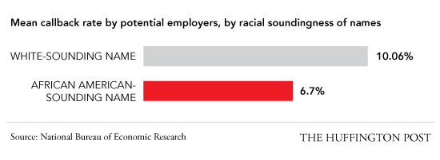

## Modeling Shortfalls

- **What social factors that impact a child's achievement are absent from this statistical model?**
- **How is circularity at play in these factors?**

## Modeling Achievement

### If our goal is to increase a child's achievement then we must focus on contextual factors that we can plausibly manipulate (e.g. discrimination, education, pollution, socioeconomic status, etc.) unlike gender and race.

## Model Construction Best Practices

### Modelling measures should reflect the construct of interest (e.g. years of schooling \(\neq\) education if quality of education differs)